# Tugas Hands On 1

### 2. **Menentukan Threshold**

Kita perlu menetapkan **threshold** atau ambang batas, yaitu level amplitudo minimum yang diperbolehkan untuk melewati "gate". Sinyal audio dengan amplitudo di bawah threshold akan diredam (mute), sedangkan sinyal di atas threshold akan dibiarkan lewat.

### 3. **Membuat Masking**

Masking digunakan untuk menentukan bagian audio mana yang berada di bawah threshold dan harus diredam.

### 4. **Terapkan Noise Gate**

Pada bagian audio yang amplitudonya berada di bawah threshold, kita menerapkan pengurangan atau penghilangan sinyal.

### 5. **Simpan Hasil Audio**

Setelah noise gate diterapkan, simpan hasilnya ke file audio baru.

### Opsi Tambahan untuk Noise Gate:

- **Attack Time** dan **Release Time**: Noise gate sering kali memiliki **attack time** (waktu yang dibutuhkan untuk membuka gate) dan **release time** (waktu untuk menutup gate setelah sinyal turun di bawah threshold). Ini bisa ditambahkan untuk memberikan kontrol yang lebih halus.
- **Knee**: Dalam beberapa noise gate, ada konsep "knee", yang memungkinkan transisi yang lebih halus antara sinyal yang melewati gate dan yang tidak.

### Penyesuaian:

- **Threshold**: Sesuaikan threshold berdasarkan tingkat kebisingan yang ingin kamu hilangkan. Misalnya, jika noise berada pada level yang sangat rendah, threshold bisa lebih tinggi.
- **Ratio**: Kamu juga bisa menambahkan pengaturan **ratio** untuk menentukan seberapa agresif gate akan memblokir sinyal di bawah threshold.

Dengan mengikuti langkah-langkah ini, kamu dapat menerapkan **noise gate** pada audio untuk menghilangkan kebisingan yang tidak diinginkan. Jika ada pertanyaan lebih lanjut atau jika kamu ingin menambahkan fitur lain pada noise gate, beri tahu saya!

```python
import soundfile as sf
import numpy as np
import os
import wave
import matplotlib.pyplot as plt
import librosa
import librosa.display
```

```python
noisegatesample = os.path.join(os.getcwd(), 'data', 'aboutme.wav')
```

```python
# Periksa jika file tidak ditemukan
if not os.path.exists(noisegatesample):
    print(f"File {noisegatesample} not found.")
    exit()
```

```python
# Membaca file WAV
with wave.open(noisegatesample, 'r') as wav_file:
    frames_noisegate = wav_file.readframes(-1)
    sample_noisegate = np.frombuffer(frames_noisegate, dtype='int16')
    fr_noisegate = wav_file.getframerate()

    # Mendapatkan informasi channel
    channel_noisegate = wav_file.getnchannels()
```

```python
# Tampilkan informasi file WAV
print(f"Isi dari data audio: {sample_noisegate}")
print(f"Panjang data audio: {len(sample_noisegate)}")
print(f"Sampling rate audio: {fr_noisegate}")
print(f"Jumlah channel audio: {channel_noisegate}")
```

```
Isi dari data audio: [0 0 0 ... 0 0 0]
Panjang data audio: 1082880
Sampling rate audio: 48000
Jumlah channel audio: 1
```

```python
# Membuat sumbu waktu
time_axis_original = np.linspace(0, len(sample_noisegate) / fr_noisegate, len(sample_noisegate))

# Plotting audio original
plt.figure(figsize=(18, 5))
plt.plot(time_axis_original, sample_noisegate)
plt.title('Waveform Audio Original')
plt.xlabel('Waktu (detik)')
plt.show()
```

[output not shown]

```python
# Tentukan threshold untuk noise gate
threshold = 0.01
```

```python
# Buat mask untuk menentukan bagian audio di bawah threshold
mask = np.abs(sample_noisegate) > threshold
```

```python
sample_noisegate_gated = sample_noisegate*mask
```

```python
# Simpan hasil audio setelah diterapkan noise gate
sf.write('data/aboutme_noise_gate.wav', sample_noisegate_gated, sr)
```

```python
aboutme_noise_gate = os.path.join(os.getcwd(), 'data', 'aboutme_noise_gate.wav')
```

```python
# WAV file
with wave.open(aboutme_noise_gate, 'r') as wav_file:
    frames_noise_gate = wav_file.readframes(-1)
    sample_noise_gate = np.frombuffer(frames_noise_gate, dtype='int16')
    fr_noise_gate = wav_file.getframerate()

    # Mendapatkan informasi channel
    channel_noise_gate = wav_file.getnchannels()
```

```python
print(f"Isi dari data audio: {sample_noise_gate}")
print(f"Panjang data audio: {len(sample_noise_gate)}")
print(f"Sampling rate audio: {fr_noise_gate}")
print(f"Jumlah channel audio: {channel_noise_gate}")
```

```
Isi dari data audio: [0 0 0 ... 0 0 0]
Panjang data audio: 1082880
Sampling rate audio: 22050
Jumlah channel audio: 1
```

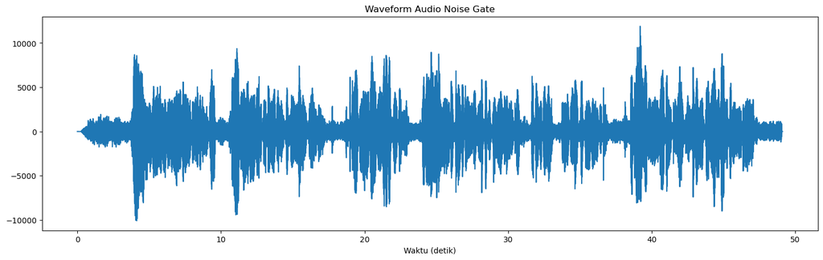

```python
# Tampilkan waveform audio noise gate
time_axis_noise_gate = np.linspace(0, len(sample_noise_gate) / fr_noise_gate, len(sample_noise_gate))

plt.figure(figsize=(18, 5))
plt.plot(time_axis_noise_gate, sample_noise_gate)
plt.title('Waveform Audio Noise Gate')
plt.xlabel('Waktu (detik)')
plt.show()
```